# AFC

Majda & Ruxue

# Chargement des library

```r
library(tidyr) #Gérer les dataframes
library(dplyr) #Gérer les dataframes
library(lubridate) #Gérer les dates
library(FactoMineR)
```

# Chargement des données

```r
rm(list=ls())
data <- read.csv("weatherAUS.csv")
str(data)
```

```
## 'data.frame':    145460 obs. of  23 variables:
##  $ Date         : Factor w/ 3436 levels "2007-11-01","2007-11-02",..: 397 398 399 400 401 402 403 404 405 406 ...
##  $ Location     : Factor w/ 49 levels "Adelaide","Albany",..: 3 3 3 3 3 3 3 3 3 3 ...
##  $ MinTemp      : num  13.4 7.4 12.9 9.2 17.5 14.6 14.3 7.7 9.7 13.1 ...
##  $ MaxTemp      : num  22.9 25.1 25.7 28 32.3 29.7 25 26.7 31.9 30.1 ...
##  $ Rainfall     : num  0.6 0 0 0 1 0.2 0 0 0 1.4 ...
##  $ Evaporation  : num  NA NA NA NA NA NA NA NA NA NA ...
##  $ Sunshine     : num  NA NA NA NA NA NA NA NA NA NA ...
##  $ WindGustDir  : Factor w/ 16 levels "E","ENE","ESE",..: 14 15 16 5 14 15 14 14 7 14 ...
##  $ WindGustSpeed: int  44 44 46 24 41 56 50 35 80 28 ...
##  $ WindDir9am   : Factor w/ 16 levels "E","ENE","ESE",..: 14 7 14 10 2 14 13 11 10 9 ...
##  $ WindDir3pm   : Factor w/ 16 levels "E","ENE","ESE",..: 15 16 16 1 8 14 14 14 8 11 ...
##  $ WindSpeed9am : int  20 4 19 11 7 19 20 6 7 15 ...
##  $ WindSpeed3pm : int  24 22 26 9 20 24 24 17 28 11 ...
##  $ Humidity9am  : int  71 44 38 45 82 55 49 48 42 58 ...
##  $ Humidity3pm  : int  22 25 30 16 33 23 19 19 9 27 ...
##  $ Pressure9am  : num  1008 1011 1008 1018 1011 ...
##  $ Pressure3pm  : num  1007 1008 1009 1013 1006 ...
##  $ Cloud9am     : int  8 NA NA NA 7 NA 1 NA NA NA ...
##  $ Cloud3pm     : int  NA NA 2 NA 8 NA NA NA NA NA ...
##  $ Temp9am      : num  16.9 17.2 21 18.1 17.8 20.6 18.1 16.3 18.3 20.1 ...
##  $ Temp3pm      : num  21.8 24.3 23.2 26.5 29.7 28.9 24.6 25.5 30.2 28.2 ...
##  $ RainToday    : Factor w/ 2 levels "No","Yes": 1 1 1 1 1 1 1 1 1 2 ...
##  $ RainTomorrow : Factor w/ 2 levels "No","Yes": 1 1 1 1 1 1 1 1 2 1 ...
```

# Suppression des variables inutiles : Evaporation, Sunshine, Cloud9am, Cloud3pm

```r
data = data[, -c(6, 7, 18, 19)]
head(data)
```

```
##         Date Location MinTemp MaxTemp Rainfall WindGustDir WindGustSpeed
## 1 2008-12-01   Albury    13.4    22.9      0.6           W            44
## 2 2008-12-02   Albury     7.4    25.1      0.0         WNW            44
## 3 2008-12-03   Albury    12.9    25.7      0.0         WSW            46
## 4 2008-12-04   Albury     9.2    28.0      0.0          NE            24
## 5 2008-12-05   Albury    17.5    32.3      1.0           W            41
## 6 2008-12-06   Albury    14.6    29.7      0.2         WNW            56
##   WindDir9am WindDir3pm WindSpeed9am WindSpeed3pm Humidity9am Humidity3pm
## 1          W        WNW           20           24          71          22
## 2        NNW        WSW            4           22          44          25
## 3          W        WSW           19           26          38          30
## 4         SE          E           11            9          45          16
## 5        ENE         NW            7           20          82          33
## 6          W          W           19           24          55          23
##   Pressure9am Pressure3pm Temp9am Temp3pm RainToday RainTomorrow
## 1      1007.7      1007.1    16.9    21.8        No           No
## 2      1010.6      1007.8    17.2    24.3        No           No
## 3      1007.6      1008.7    21.0    23.2        No           No
## 4      1017.6      1012.8    18.1    26.5        No           No
## 5      1010.8      1006.0    17.8    29.7        No           No
## 6      1009.2      1005.4    20.6    28.9        No           No
```

# Suppression des lignes contiennes des NA

```r
data = data %>% drop_na()
```

# Ajout des variables Year

```r
data <- mutate(data, Date = as.Date(Date))
data = data %>% mutate(Year = year(Date))
head(data)
```

```
##         Date Location MinTemp MaxTemp Rainfall WindGustDir WindGustSpeed
## 1 2008-12-01   Albury    13.4    22.9      0.6           W            44
## 2 2008-12-02   Albury     7.4    25.1      0.0         WNW            44
## 3 2008-12-03   Albury    12.9    25.7      0.0         WSW            46
## 4 2008-12-04   Albury     9.2    28.0      0.0          NE            24
## 5 2008-12-05   Albury    17.5    32.3      1.0           W            41
## 6 2008-12-06   Albury    14.6    29.7      0.2         WNW            56
##   WindDir9am WindDir3pm WindSpeed9am WindSpeed3pm Humidity9am Humidity3pm
## 1          W        WNW           20           24          71          22
## 2        NNW        WSW            4           22          44          25
## 3          W        WSW           19           26          38          30
## 4         SE          E           11            9          45          16
## 5        ENE         NW            7           20          82          33
## 6          W          W           19           24          55          23
##   Pressure9am Pressure3pm Temp9am Temp3pm RainToday RainTomorrow Year
## 1      1007.7      1007.1    16.9    21.8        No           No 2008
## 2      1010.6      1007.8    17.2    24.3        No           No 2008
## 3      1007.6      1008.7    21.0    23.2        No           No 2008
## 4      1017.6      1012.8    18.1    26.5        No           No 2008
## 5      1010.8      1006.0    17.8    29.7        No           No 2008
## 6      1009.2      1005.4    20.6    28.9        No           No 2008
```

# Group by les lignes par location et par année

```r
by_loca <- data %>% group_by(Location, Year)
head(by_loca)
```

```
## # A tibble: 6 x 20
## # Groups:   Location, Year [1]
##   Date       Location MinTemp MaxTemp Rainfall WindGustDir WindGustSpeed
##   <date>     <fct>      <dbl>   <dbl>    <dbl> <fct>               <int>
## 1 2008-12-01 Albury      13.4    22.9      0.6 W                      44
## 2 2008-12-02 Albury       7.4    25.1      0   WNW                    44
## 3 2008-12-03 Albury      12.9    25.7      0   WSW                    46
## 4 2008-12-04 Albury       9.2    28        0   NE                     24
## 5 2008-12-05 Albury      17.5    32.3      1   W                      41
## 6 2008-12-06 Albury      14.6    29.7      0.2 WNW                    56
## # … with 13 more variables: WindDir9am <fct>, WindDir3pm <fct>,
## #   WindSpeed9am <int>, WindSpeed3pm <int>, Humidity9am <int>,
## #   Humidity3pm <int>, Pressure9am <dbl>, Pressure3pm <dbl>, Temp9am <dbl>,
## #   Temp3pm <dbl>, RainToday <fct>, RainTomorrow <fct>, Year <dbl>
```

# Visualisation de nombre de jours effectifs par année par ville

```r
head(by_loca %>% count())
```

```
## # A tibble: 6 x 3
## # Groups:   Location, Year [6]
##   Location  Year     n
##   <fct>    <dbl> <int>
## 1 Adelaide  2008   147
## 2 Adelaide  2009   331
## 3 Adelaide  2010   317
## 4 Adelaide  2011   300
## 5 Adelaide  2012   284
## 6 Adelaide  2013   269
```

# Extraire 2300 lignes pour chaque ville

```r
by_year = by_loca %>% filter(Year >= 2010 & Year <= 2017)
data_year<- by_year %>% group_by(Location)
data_year = data_year %>% filter(n() > 2300)
data_year <- data_year %>% slice(1:2300)
head(data_year)
```

```
## # A tibble: 6 x 20
## # Groups:   Location [1]
##   Date       Location MinTemp MaxTemp Rainfall WindGustDir WindGustSpeed
##   <date>     <fct>      <dbl>   <dbl>    <dbl> <fct>               <int>
## 1 2010-01-01 AliceSp…    27.2    41.3      0   SSE                    59
## 2 2010-01-02 AliceSp…    25.3    35.6      0   SE                     50
## 3 2010-01-03 AliceSp…    21.3    35.5      0   SSE                    43
## 4 2010-01-04 AliceSp…    19.9    35.8      0   ESE                    39
## 5 2010-01-05 AliceSp…    24.2    34.6      0   S                      37
## 6 2010-01-06 AliceSp…    23.5    31.6      0.4 ESE                    61
## # … with 13 more variables: WindDir9am <fct>, WindDir3pm <fct>,
## #   WindSpeed9am <int>, WindSpeed3pm <int>, Humidity9am <int>,
## #   Humidity3pm <int>, Pressure9am <dbl>, Pressure3pm <dbl>, Temp9am <dbl>,
## #   Temp3pm <dbl>, RainToday <fct>, RainTomorrow <fct>, Year <dbl>
```

#Etudions la direction du vent pour chaque ville

```r
list = data_year %>% group_by(Location, WindGustDir) %>% count()
```

#Construction d’un nouveau dataframe du type Election President #Individus : les villes #Variables : les direction du WindGustDir

```r
windDir = list$WindGustDir[1:16]
ville = (list %>% group_by(Location) %>% slice(1))$Location

#DataFrame que nous allons faire AFD
dataAFD = matrix(data=NA,nrow=25,ncol=16)
rownames(dataAFD)=ville
colnames(dataAFD)=windDir

for (i in 1:12)
  dataAFD[,i]=(data_year %>% filter(WindGustDir == windDir[i]) %>% count())$n
for (i in 14:16)
  dataAFD[,i]=(data_year %>% filter(WindGustDir == windDir[i]) %>% count())$n

#Cas particulier pour SW : il faut ajouter 0 pour Cairns
windSW = (data_year %>% filter(WindGustDir == windDir[13]) %>% count())
dataAFD[,13]= c((windSW$n)[1:4],0,(windSW$n)[5:24])

#Convertir en type DataFrame
dataAFD = as.data.frame(dataAFD)
```

```r
head(dataAFD)
```

```
##                E ENE ESE   N  NE NNE NNW  NW   S  SE SSE SSW  SW   W WNW WSW
## AliceSprings 355 137 491 112  61  50  92  63 152 309 196  85  65  40  43  49
## Ballarat      10   5  95 402  22 211 132  80 222 281 164  91 107 197 120 161
## Bendigo       17  69  13 216 128 144  88 121 164 127 411  92 189 172 163 186
## Brisbane     446 343 192  15 276  78  18  10  22 218 132  27  60 265  81 117
## Cairns       141 180 212  72 157 136   9   6 182 770 386  13   0  13  16   7
## Cobar        170 164 133  89 160 154  83  87 153  68  89 188 311 124  96 231
```

```r
str(dataAFD)
```

```
## 'data.frame':    25 obs. of  16 variables:
##  $ E  : num  355 10 17 446 141 170 391 86 19 4 ...
##  $ ENE: num  137 5 69 343 180 164 154 86 14 3 ...
##  $ ESE: num  491 95 13 192 212 133 312 132 93 8 ...
##  $ N  : num  112 402 216 15 72 89 225 103 128 744 ...
##  $ NE : num  61 22 128 276 157 160 87 125 31 7 ...
##  $ NNE: num  50 211 144 78 136 154 75 280 18 93 ...
##  $ NNW: num  92 132 88 18 9 83 164 51 496 67 ...
##  $ NW : num  63 80 121 10 6 87 217 121 440 36 ...
##  $ S  : num  152 222 164 22 182 153 31 260 103 326 ...
##  $ SE : num  309 281 127 218 770 68 138 352 195 65 ...
##  $ SSE: num  196 164 411 132 386 89 47 486 77 306 ...
##  $ SSW: num  85 91 92 27 13 188 37 8 177 117 ...
##  $ SW : num  65 107 189 60 0 311 24 18 188 184 ...
##  $ W  : num  40 197 172 265 13 124 79 76 82 125 ...
##  $ WNW: num  43 120 163 81 16 96 272 105 136 53 ...
##  $ WSW: num  49 161 186 117 7 231 47 11 103 162 ...
```

# ————————————- Un breif PCA —————————————–

```r
res = PCA(dataAFD)
```

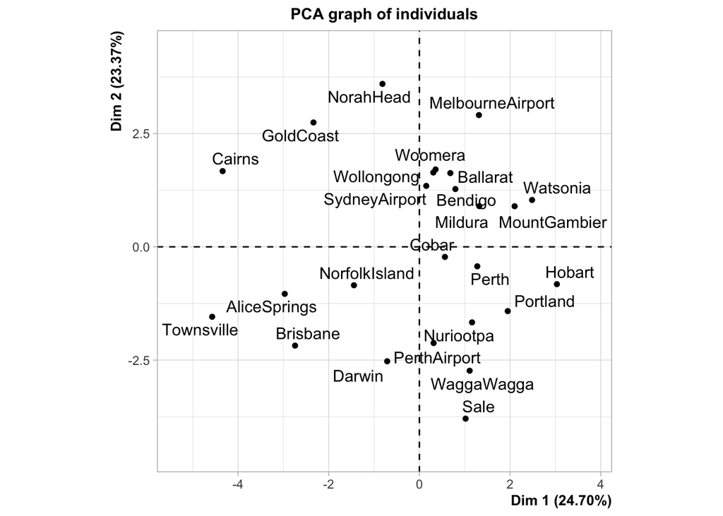

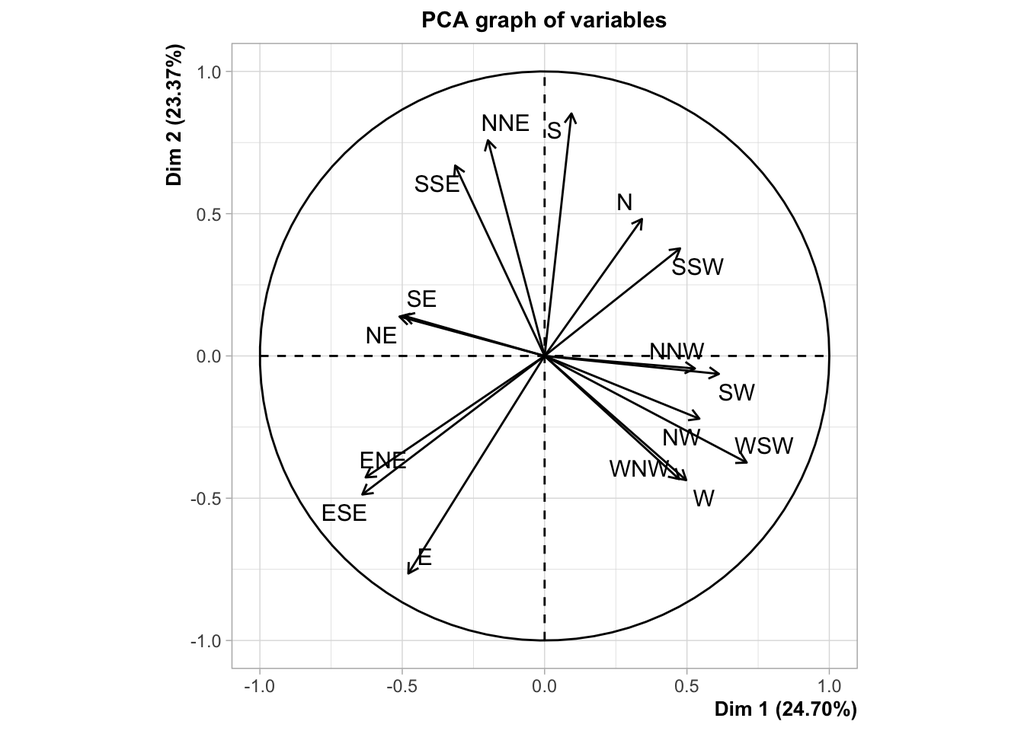

On observe que - le premier axe représente plus l’opposition East / West - le deuxieme axe représente plus l’opposition SN / WE

# ——————————— AFD commence ———————————————-

## La part de chaque direction du vent

apply(data, 2, sum) : sommer sur les colonnes de data

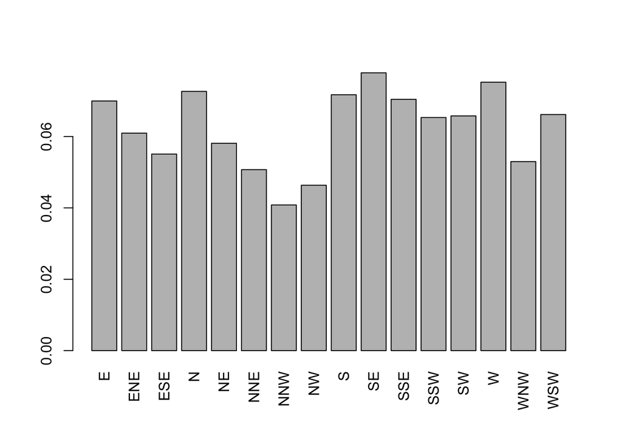

```r
barplot(apply(dataAFD, 2, sum)/sum(dataAFD), las=3)
```

On observe que les vents qui viennent de l’est et de l’ouest sont plus représentatifs.

## Les villes en terme de la direction du vent

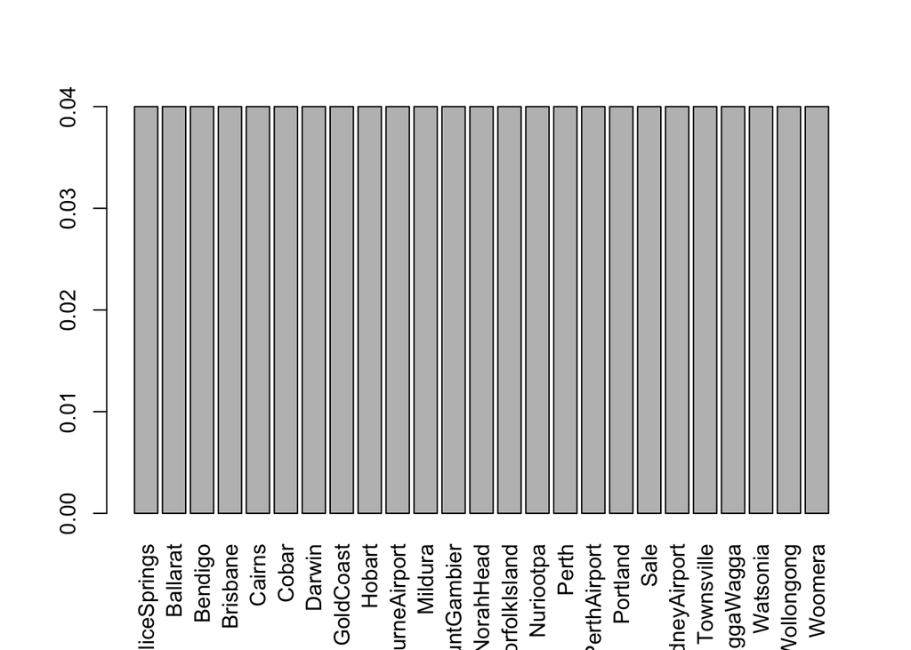

```r
barplot(apply(dataAFD, 1, sum)/sum(dataAFD), las=3)
```

Les parts de chaque ville sont équitables, car nous avons extrait 2300 jours pour chaque ville.

```r
chisq.test(dataAFD)
```

```
##
##  Pearson's Chi-squared test
##
## data:  dataAFD
## X-squared = 36994, df = 360, p-value < 2.2e-16
```

pvalue < 0.05 => On rejette H0 => les deux variables sont liées, et ne sont donc pas indépendantes

```r
res=CA(dataAFD)
```

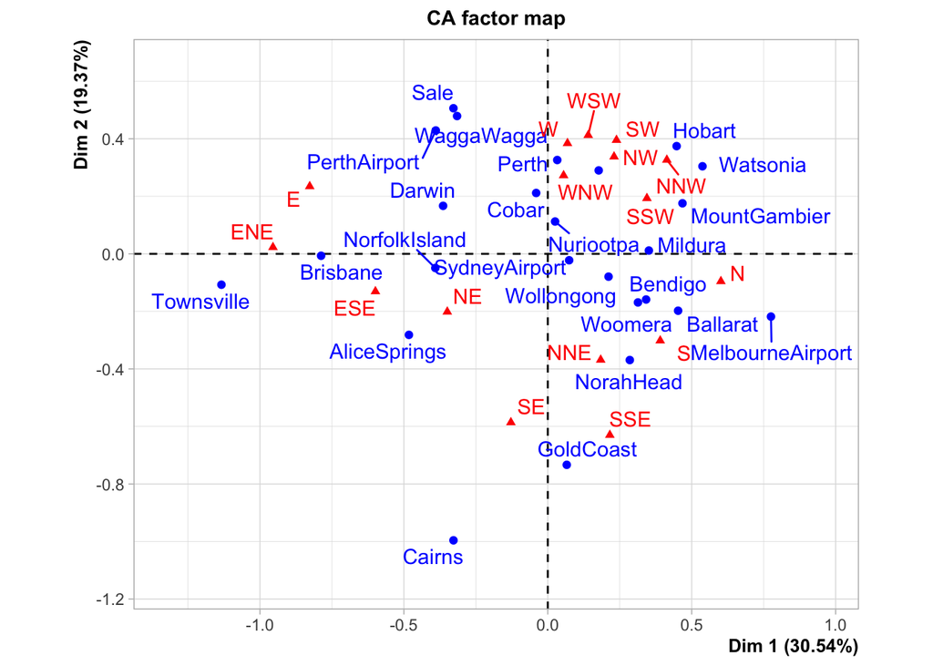

```r
res$eig
```

```
##          eigenvalue percentage of variance cumulative percentage of variance
## dim 1  0.1964736229             30.5379632                          30.53796
## dim 2  0.1246412191             19.3730278                          49.91099
## dim 3  0.0945536898             14.6965127                          64.60750
## dim 4  0.0601395015              9.3475035                          73.95501
## dim 5  0.0559641407              8.6985258                          82.65353
## dim 6  0.0356780079              5.5454451                          88.19898
## dim 7  0.0265100467              4.1204657                          92.31944
## dim 8  0.0181419052              2.8198026                          95.13925
## dim 9  0.0084626342              1.3153502                          96.45460
## dim 10 0.0071770775              1.1155356                          97.57013
## dim 11 0.0061509789              0.9560488                          98.52618
## dim 12 0.0043996094              0.6838328                          99.21001
## dim 13 0.0031624725              0.4915442                          99.70156
## dim 14 0.0012590730              0.1956981                          99.89726
## dim 15 0.0006610278              0.1027438                         100.00000
```

On garde 5 axes pour que l’information soit représentée de manière satisfaisante (82,6%).

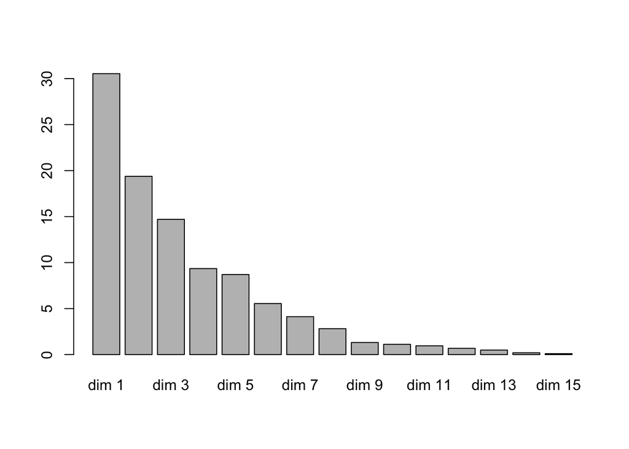

```r
barplot(res$eig[, 2])
```

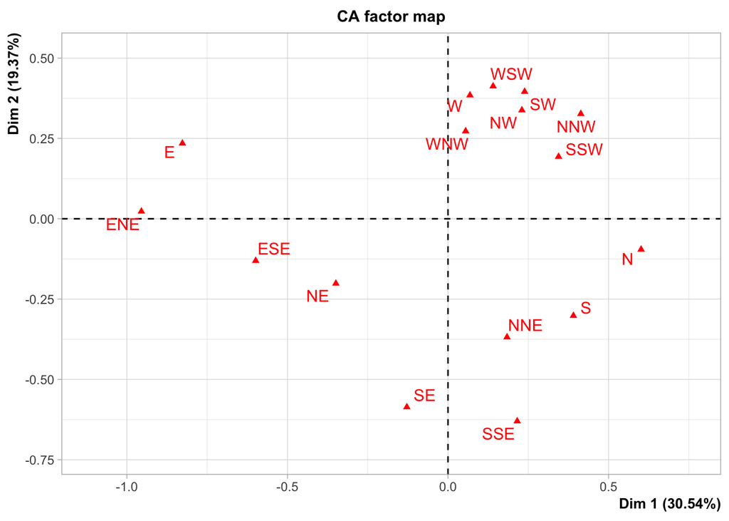

```r
plot(res, invisible="row")
```

```r
res$col$cos2
```

```
##           Dim 1       Dim 2       Dim 3        Dim 4        Dim 5
## E   0.739960668 0.059552455 0.033777853 0.0256752738 1.687510e-02
## ENE 0.701422948 0.000406627 0.147644209 0.0020058898 4.286325e-02
## ESE 0.503013346 0.023939728 0.152460544 0.0214188442 6.682947e-02
## N   0.408338271 0.010291511 0.006055376 0.0764145849 4.694717e-01
## NE  0.180593770 0.060048714 0.487458055 0.0645600319 1.049836e-01
## NNE 0.090917049 0.365388791 0.110530671 0.0055382944 6.434570e-02
## NNW 0.174157511 0.108621695 0.124489086 0.4785897306 5.245032e-02
## NW  0.087445548 0.188441783 0.186927879 0.4235875569 6.910202e-03
## S   0.359680424 0.214512748 0.132848465 0.0001122630 2.300063e-02
## SE  0.022282723 0.466040010 0.281452689 0.0033920901 2.118618e-02
## SSE 0.078645538 0.671609645 0.021329470 0.0248458590 6.690482e-03
## SSW 0.233222953 0.073531463 0.384104810 0.0650507208 8.120707e-03
## SW  0.112830570 0.310039784 0.078328737 0.0003144233 3.397276e-07
## W   0.009782678 0.309014970 0.093696749 0.2910022974 1.370675e-01
## WNW 0.009898133 0.243828812 0.183301723 0.0071408449 1.508517e-01
## WSW 0.060253511 0.519603451 0.003973319 0.2237090063 5.469098e-02
```

Direction bien représentés

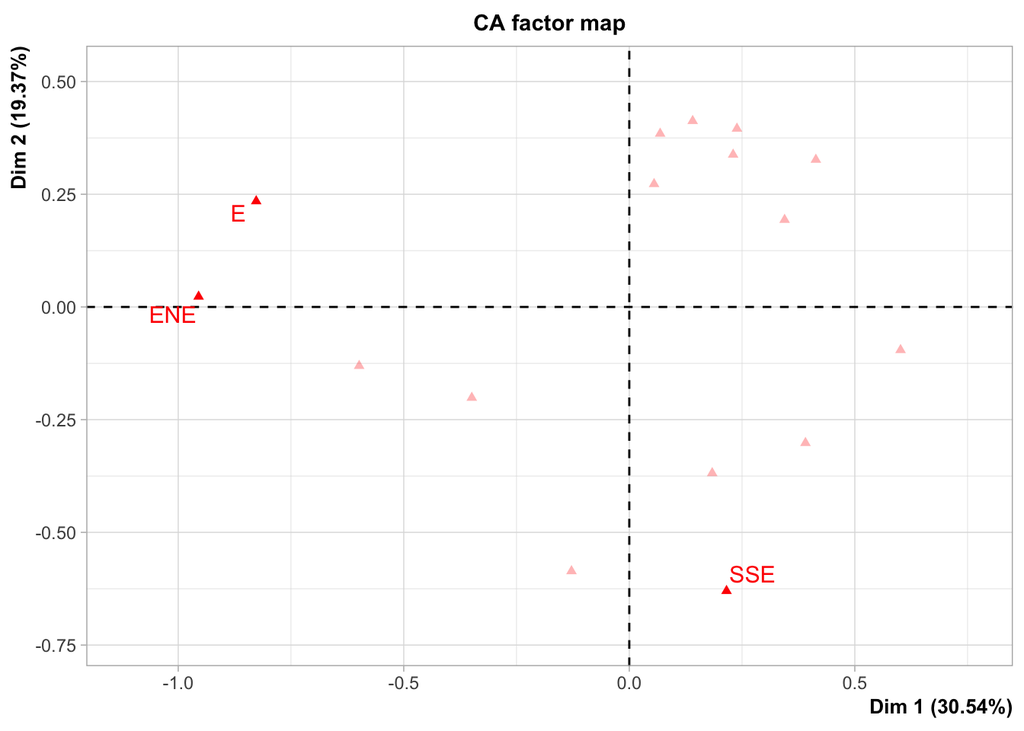

```r
plot(res, invisible="row", selectCol="cos2 0.6")
```

```r
res$col$contrib
```

```
##           Dim 1      Dim 2       Dim 3       Dim 4        Dim 5
## E   24.35584115  3.0898453  2.31021452  2.76092119 1.950003e+00
## ENE 28.27713513  0.0258401 12.36794729  0.26418426 6.066454e+00
## ESE 10.05459886  0.7543050  6.33240199  1.39870363 4.689728e+00
## N   13.37229783  0.5312607  0.41205276  8.17535542 5.397464e+01
## NE   3.60564701  1.8898473 20.22290154  4.21103266 7.358621e+00
## NNE  0.87219422  5.5254246  2.20331428  0.17357547 2.167114e+00
## NNW  3.55447913  3.4945632  5.27947586 31.91108449 3.758169e+00
## NW   1.25004463  4.2462698  5.55248847 19.78223873 3.467951e-01
## S    5.56730879  5.2338850  4.27278284  0.00567688 1.249864e+00
## SE   0.65065245 21.4509521 17.07701580  0.32358816 2.171841e+00
## SSE  1.66548262 22.4194786  0.93858122  1.71895482 4.974138e-01
## SSW  3.94190046  1.9590708 13.48993575  3.59195516 4.818619e-01
## SW   1.90706347  8.2603482  2.75096623  0.01736191 2.015875e-05
## W    0.17914958  8.9203140  3.56540075 17.41000538 8.812254e+00
## WNW  0.08142936  3.1619525  3.13343050  0.19192068 4.356848e+00
## WSW  0.66477532  9.0366428  0.09109022  8.06344117 2.118374e+00
```

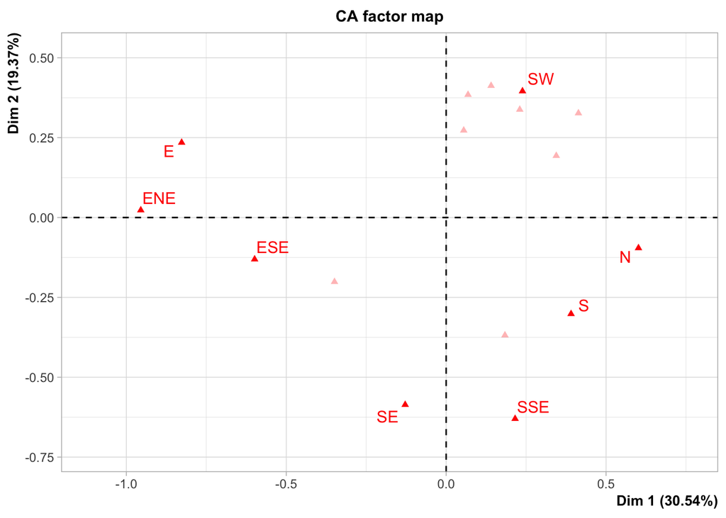

```r
plot(res, invisible="row", selectCol="contrib 8")
```

Axe 1: ENE / N Axe 2: SW / SE

##Regarder axe 3 et 4

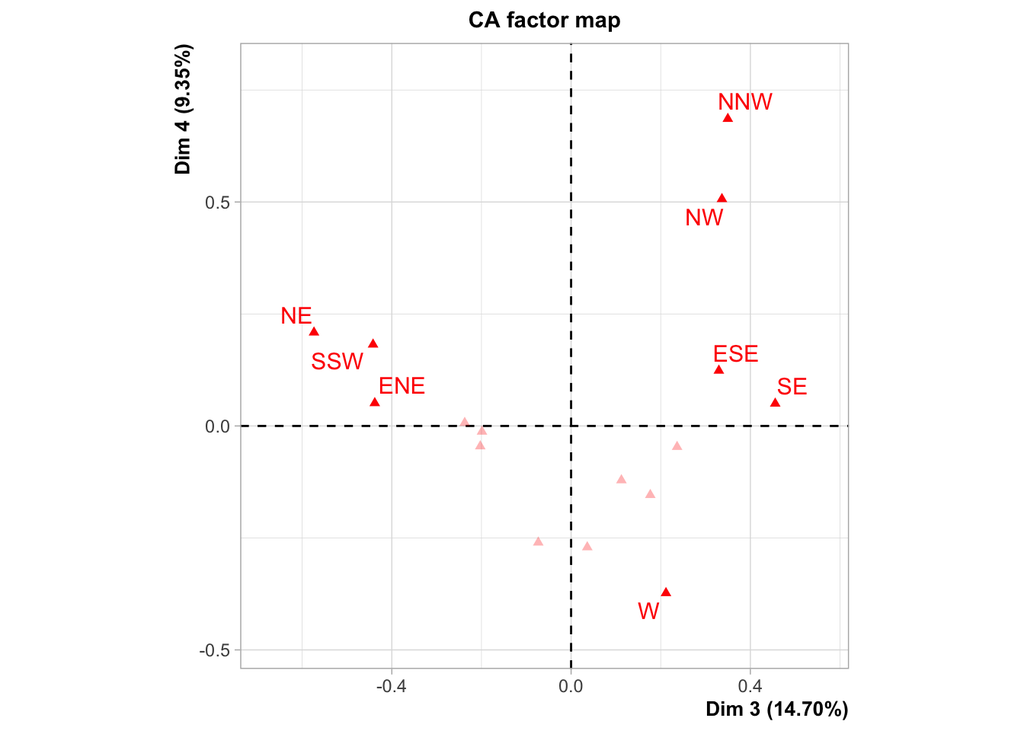

```r
plot(res, invisible="row", selectCol="contrib 8", axe=c(3, 4))
```

Axe 3: NE / SE Axe 4: NNW / W

##Regarder axe 1 et 5

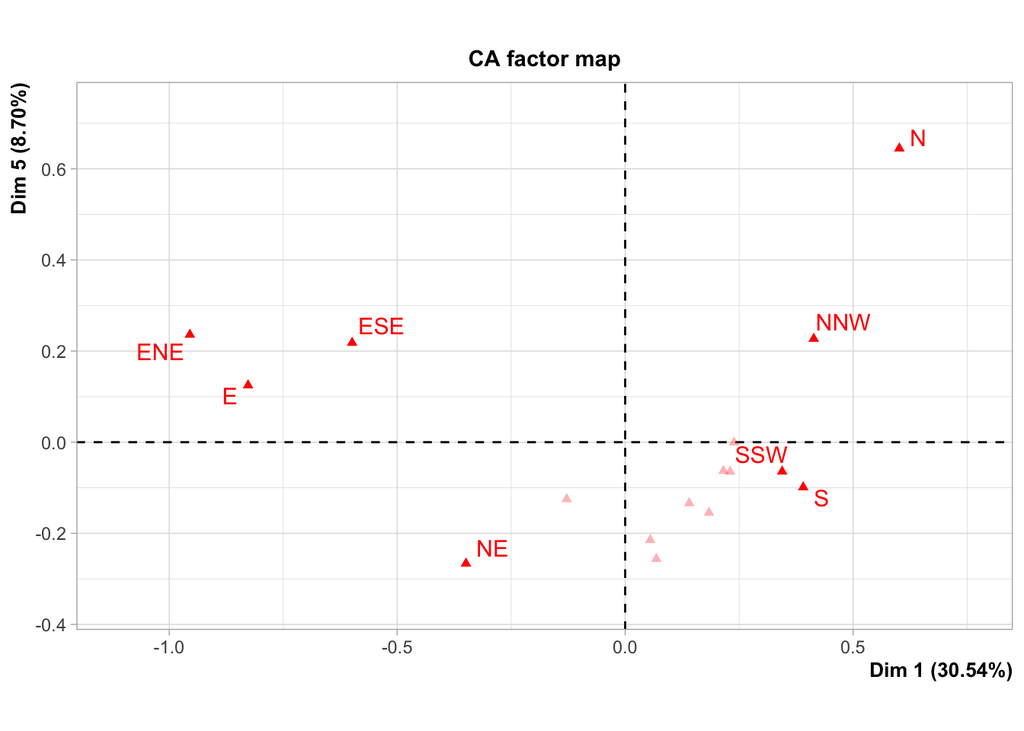

```r
plot(res, invisible="row", selectCol="contrib 8", axe=c(1, 5))
```

Axe 5: N / NE

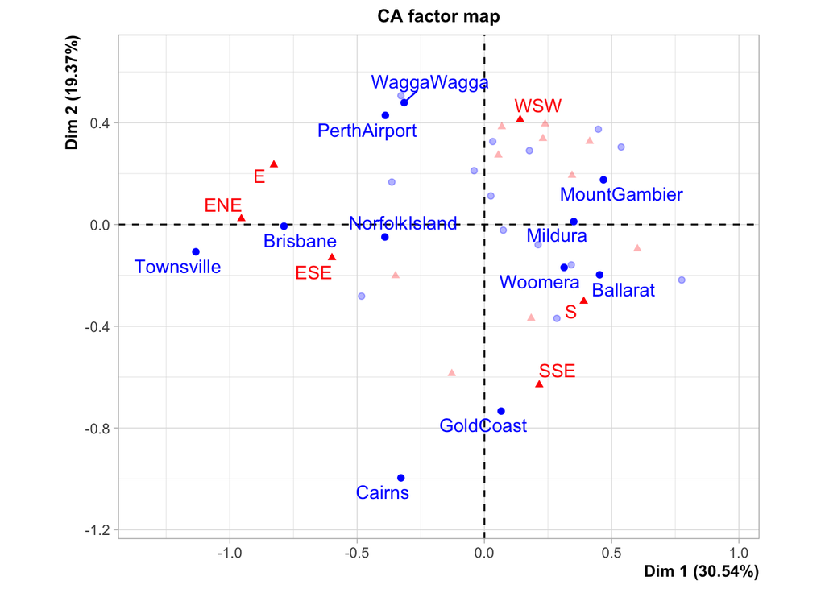

```r
plot(res, selectRow = "cos2 0.6", selectCol = "cos2 0.5")
```

- Il y a des régions dont les résultats sont proches des résultats nationaux : des points qui sont proches du centre de gravité, par exemple : Mildura.
- Il y a des régions qui se ressemblent : des points bleus confondus, par exemple : WaggaWagga et PerthAirport.
- Townsville a surtout des vents qui viennent du ENE.
- Cairns a peu de vent qui vient du WSW.

Si on regarde un deuxième plan

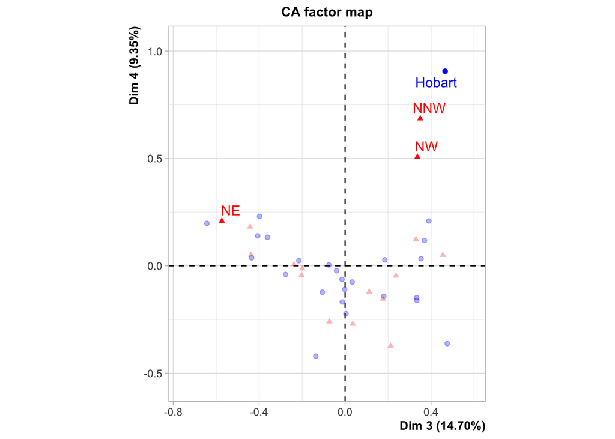

```r
plot(res, selectRow = "cos2 0.6", selectCol = "cos2 0.5", axe=c(3, 4))
```

- Hobart a surtout du vent vient de Nord-West

```r
profil.Mildura = round(dataAFD["Mildura", ]/sum(dataAFD["Mildura", ]), 2)
profil.Townsville = round(dataAFD["Townsville", ]/sum(dataAFD["Townsville", ]), 2)
profil.Hobart = round(dataAFD["Hobart", ]/sum(dataAFD["Hobart", ]), 2)
profil.Cairns = round(dataAFD["Cairns", ]/sum(dataAFD["Cairns", ]), 2)
profil.moyen = round(apply(dataAFD, 2, sum)/sum(apply(dataAFD, 2, sum)), 2)

M = rbind(profil.Mildura, profil.Townsville, profil.Hobart, profil.Cairns, moyen=profil.moyen)
M
```

```
##               E  ENE  ESE    N   NE  NNE  NNW   NW    S   SE  SSE  SSW   SW
## Mildura    0.02 0.02 0.03 0.10 0.03 0.06 0.04 0.05 0.08 0.07 0.09 0.11 0.08
## Townsville 0.14 0.34 0.12 0.04 0.17 0.04 0.01 0.00 0.02 0.04 0.01 0.04 0.02
## Hobart     0.01 0.01 0.04 0.06 0.01 0.01 0.22 0.19 0.04 0.08 0.03 0.08 0.08
## Cairns     0.06 0.08 0.09 0.03 0.07 0.06 0.00 0.00 0.08 0.33 0.17 0.01 0.00
## moyen      0.07 0.06 0.06 0.07 0.06 0.05 0.04 0.05 0.07 0.08 0.07 0.07 0.07
##               W  WNW  WSW
## Mildura    0.08 0.07 0.08
## Townsville 0.00 0.00 0.00
## Hobart     0.04 0.06 0.04
## Cairns     0.01 0.01 0.00
## moyen      0.08 0.05 0.07
```

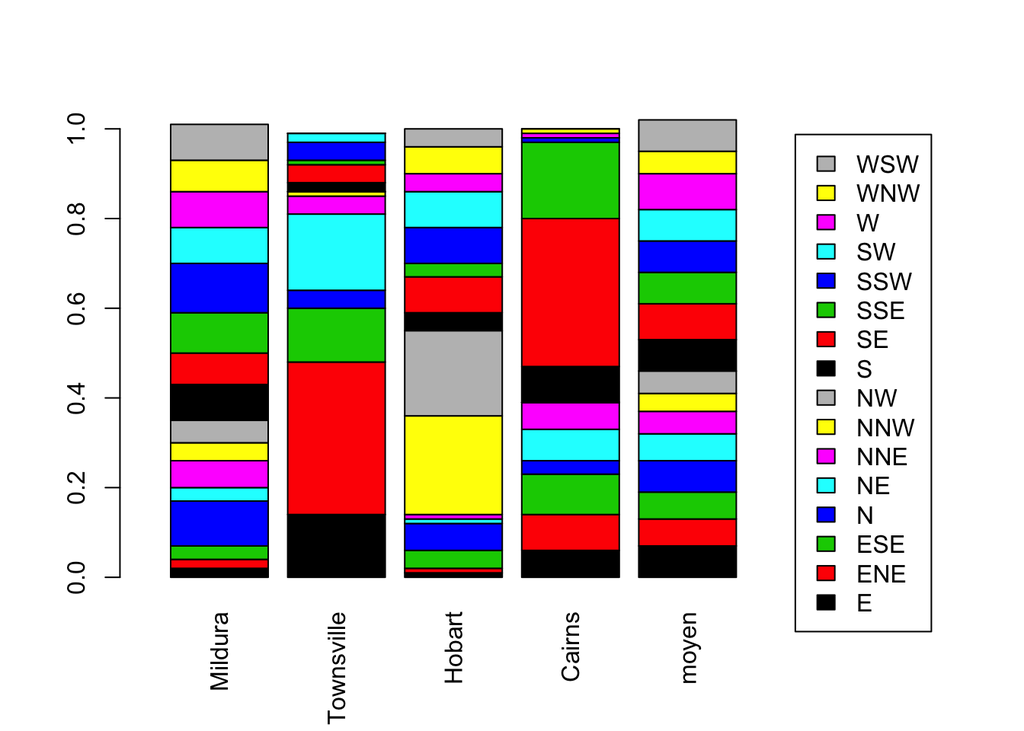

```r
barplot(t(M), xlim=c(0, ncol(t(M)) + 3), col=1:16, legend.text=colnames(dataAFD), args.legend = list(x=ncol(t(M)) + 3), las=3)
```